# Biol551 Final Project (Without Shiny App)

Heather Carstensen

5/8/2022

```r
#### Loading Libraries ####

library(tidyverse)
library(here)
library(shiny)
library(networkD3)
library(htmlwidgets)
library(webshot)
library(magick)
```

## *Pristionchus pacificus* life cycle

*Pristionchus pacificus* is a free-living, microscopic nematode (roundworm) that associates with a species of beetle, *Exomala orientalis*.

When environmental conditions are favorable, *P. pacificus* continuously develop through the embryonic stage and four larval stages before reaching reproductive adulthood, a process that takes about three days.

When environmental conditions are unfavorable, including lack of food, high population density, and high temperature, young larvae instead have the option of entering an alternate stress-resistant larval stage called dauer. This stage does not eat and will remain developmentally arrested until the dauer encounters favorable conditions such as food, triggering resumption of development. The dauer stage is also considered to be the host-seeking stage.

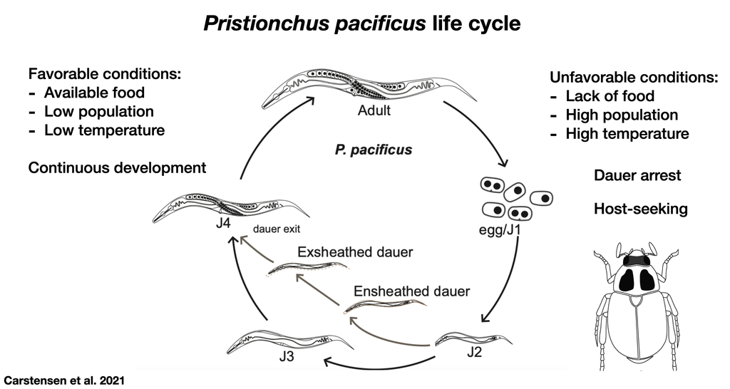

```r
image_read(here("Images", "lifecycle.png"))  #Read in life cycle image
```

## Is the *csu60* constitutive dauer mutant an allele of the *Ppa-hsd-2* gene?

To understand what genes regulate the dauer stage, researchers often examine mutants that exhibit dauer-related phenotypes. One such phenotype is constitutive dauer formation, Daf-c, wherein the mutant worms inappropriately enter the dauer stage even with sufficient food.

We learned from whole genome sequencing that a constitutive dauer allele, *csu60*, has a deletion that includes the gene *Ppa-hsd-2*.

*Ppa-hsd-2* is an enzyme that makes delta-7-dafachronic acid (7DA), a hormone that normally suppresses dauer formation.

To address whether deletion of *Ppa-hsd-2* is causing the *csu60* dauer phenotype, we examined whether

- feeding them 7DA
- transgenically introducing a wild-type copy of *Ppa-hsd-2*

will prevent the inappropriate dauer formation in *csu60*.

First, I will read in the related data and process it.

```r
rescue_data <- read_csv(here("data", "rescue.csv")) #Read in the data

head(rescue_data)
```

```
## # A tibble: 6 × 6
##   sample_id genotype treatment days_inc dauer non_dauer
##       <dbl> <chr>    <chr>        <dbl> <dbl>     <dbl>
## 1         1 csu60    none             5   267        26
## 2         2 csu60    none             5   397        21
## 3         3 csu60    none             5   461        26
## 4         4 csu60    none             5   462        15
## 5         5 csu60    none             5   559        12
## 6         6 csuEx54  none             5    71       247
```

```r
#### Formatting rescue data to calculate dauer and non-dauer population percentages.

rescue_data <- rescue_data %>%  #Working with the rescue data
  mutate(total = dauer+non_dauer,  #Making a new column with total number of worms scored
         percent_dauer = (dauer/total)*100,  #Making a new column with percent dauer scored
         percent_non_dauer = (non_dauer/total)*100)  #Making a new column with percent non-dauer scored

#### Creating a summary dataframe of the mean dauer and non-dauer population percentages, and formatting for easy plotting.

rescue_summary <- rescue_data %>%   #Making a new summary data frame
  group_by(genotype, treatment) %>%   #Grouping by genotype and treatment
  summarise_at(c("percent_dauer", "percent_non_dauer"), mean) %>%   #Generating mean for the two percentage columns
  unite("condition", genotype:treatment)%>%   #Uniting the genotype and treatment columns into a single column called condition
  pivot_longer(cols = percent_dauer:percent_non_dauer,  #Pivoting longer
               names_to = "Variables",   #Making column of original column names called Variables
               values_to = "Values") %>%   #Making column of original values called Values
  mutate(condition = factor(condition,   #Changing the factors of the condition column
                            levels = c("csu60_none", "csuEx54_none",
                                       "csu60_EtOH", "csu60_7DA")))  #Designating the order of the levels for the condition column

head(rescue_summary)
```

```
## # A tibble: 6 × 3
##   condition  Variables         Values
##   <fct>      <chr>              <dbl>
## 1 csu60_7DA  percent_dauer       0
## 2 csu60_7DA  percent_non_dauer 100
## 3 csu60_EtOH percent_dauer      70.0
## 4 csu60_EtOH percent_non_dauer  30.0
## 5 csu60_none percent_dauer      95.1
## 6 csu60_none percent_non_dauer   4.90
```

```r
color_palette <- c("#97D2ED", "#215382")  #Creating a custom color palette

#### Writing a function to easily generate plots from the summary dataframe

rescue_plot <- function(data, x, y){  #Creating a function called rescue_plot
  ggplot(data, aes(x = {{x}},  #Starting ggplot, data, and aesthetics mapping
                   y = {{y}},  #Aesthetics mapping
                   fill = Variables)) +  #Mapping fill to Variables
    geom_col(color = "black") +  #Column geometry with black outlines on the bars
    theme_linedraw() +  #ggplot theme linedraw
    labs(x = " ",  #Remove x-axis title
         y = "Percent of population") +   #Set y-axis title
    scale_fill_manual(values = color_palette,  #Use custom color palette
                      name = "Stage",  #Set legend title
                      labels = c("Dauers", "Non-dauers"))  #Set legend labels
}
```

Next, I will plot the data to show whether feeding *csu60* mutants the exogenous 7DA hormone would rescue the Daf-c phenotype, showing that lack of the 7DA hormone is causing dauer formation.

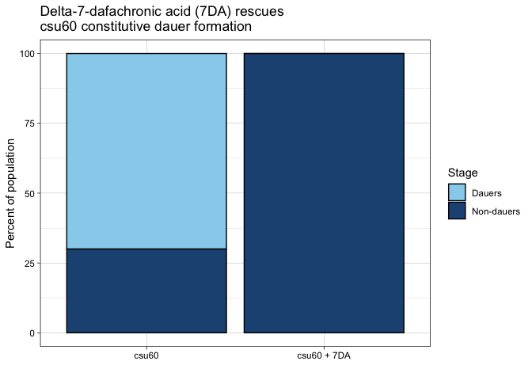

```r
rescue_summary %>%  #Start working with rescue_summary data frame
  filter(condition %in% c("csu60_EtOH", "csu60_7DA")) %>%  #Filter to control ethanol or 7DA-treated
  rescue_plot(x = condition, y = Values) +  #Start rescue_plot function with x mapped to condition and y mapped to Values
  labs(title = "Delta-7-dafachronic acid (7DA) rescues \ncsu60 constitutive dauer formation") +  #Add plot title
  scale_x_discrete(labels = c("csu60", "csu60 + 7DA"))  #Change x-axis labels
```

As expected, exogenous 7DA did rescue the constitutive dauer formation.

Next, I will plot the data showing whether introducing a wild-type copy of the *Ppa-hsd-2* gene will also reduce the inappropriate dauer formation.

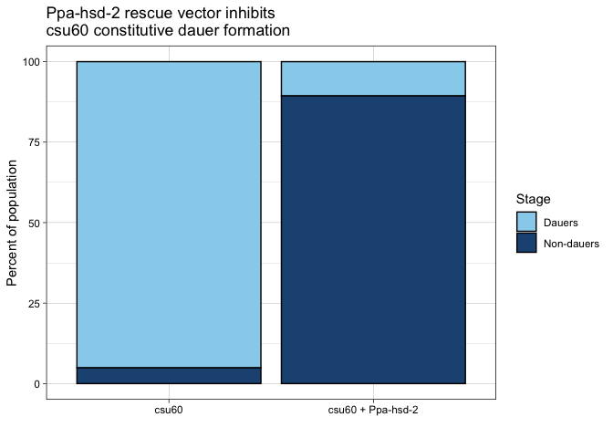

```r
rescue_summary %>%  #Start working with rescue_summary data frame
  filter(condition %in% c("csu60_none", "csuEx54_none")) %>%  #Filter to control or transgenic worms
  rescue_plot(x = condition, y = Values) +  #Start rescue_plot function with x mapped to condition and y mapped to Values
  labs(title = "Ppa-hsd-2 rescue vector inhibits \ncsu60 constitutive dauer formation") +  #Add plot title
  scale_x_discrete(labels = c("csu60", "csu60 + Ppa-hsd-2"))  #Change x-axis labels
```

As expected, the *Ppa-hsd-2* gene also rescued the dauer formation, verifying that the *csu60* Daf-c phenotype is caused by deletion of the *Ppa-hsd-2* gene.

## Does the *Ppa-hsd-2* show phenotypes related to host-seeking odortaxis?

Because dauer larvae are the host-seeking stage, they are attracted to a pheromone, Z-7-tetradece-2-one (ZTDO), which is produced by their host beetle species.

We examined *csu60* adult and dauer respones to ZTDO to see whether this mutation alters their host-seeking behavior. To do so, we utilized a chemotaxis assay, where an attractant (ZTDO in this case) and a control are pipetted on opposite sides of a plate, and worms responses to the attractant are calculated based on the proportion of worms counted near the attractant or the control.

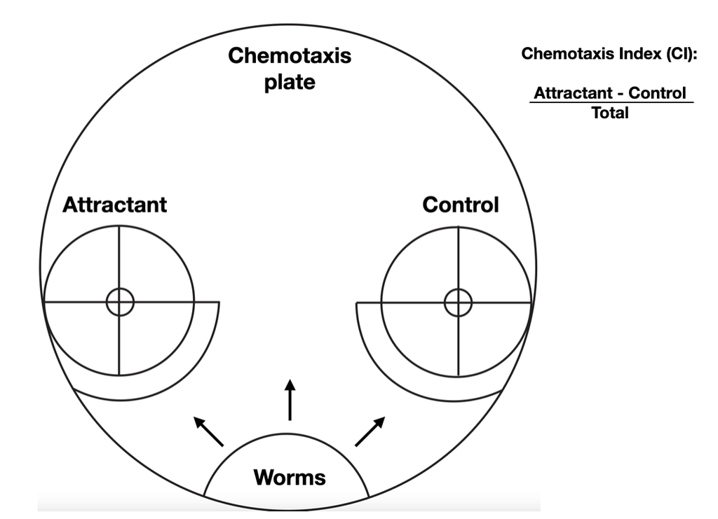

```r
image_read(here("Images", "ctx_template.png"))  #Read in chemotaxis template image
```

A chemotaxis index near 1 means high attraction, an index near -1 means high repulsion, and an index near 0 means a neutral response. Let’s read in the raw chemotaxis data, use it to calculate the chemotaxis index ((A-C)/(A+C)), and examine the *csu60* response to the beetle pheromone ZTDO.

```r
chemotaxis_data <- read_csv(here("data", "chemotaxis.csv"))  #Read in chemotaxis data

head(chemotaxis_data)
```

```
## # A tibble: 6 × 6
##   sample_id lifestage genotype treatment attracted control
##       <dbl> <chr>     <chr>    <chr>         <dbl>   <dbl>
## 1         1 adult     csu60    none             24       5
## 2         2 adult     csu60    none             33       8
## 3         3 adult     csu60    none             33       1
## 4         4 adult     csu60    none             32       0
## 5         5 adult     csu60    none             52       0
## 6         6 adult     csu60    none             23       1
```

```r
#### Analyze and prepare data for plotting

chemotaxis_data <- chemotaxis_data %>%  #Overwrite changes to data frame
  mutate(total = attracted+control,  #Make a new column with calculated total number of worms scored
         CI = ((attracted-control)/total)) %>%  #Make column calculating the chemotaxis index
  unite("condition", lifestage:treatment,  #Merging the column values for lifestage, genotype, and treatment
        remove = FALSE) %>%  #Keeping the original columns
  mutate(condition = factor(condition,  #Changing the factors for the condition column
                            levels = c('adult_PS312_none', 'dauer_PS312_none',
                                       'adult_csu60_none', 'dauer_csu60_none',
                                       'adult_csu60_no_7DA', 'adult_csu60_7DA',
                                       'adult_csu60_no_transgene', 'adult_csu60_transgene')))  %>%  #Designating these factor levels
  group_by(condition)  #Grouping by condition

head(chemotaxis_data)
```

```
## # A tibble: 6 × 9
## # Groups:   condition [1]
##   sample_id condition lifestage genotype treatment attracted control total    CI
##       <dbl> <fct>     <chr>     <chr>    <chr>         <dbl>   <dbl> <dbl> <dbl>
## 1         1 adult_cs… adult     csu60    none             24       5    29 0.655
## 2         2 adult_cs… adult     csu60    none             33       8    41 0.610
## 3         3 adult_cs… adult     csu60    none             33       1    34 0.941
## 4         4 adult_cs… adult     csu60    none             32       0    32 1
## 5         5 adult_cs… adult     csu60    none             52       0    52 1
## 6         6 adult_cs… adult     csu60    none             23       1    24 0.917
```

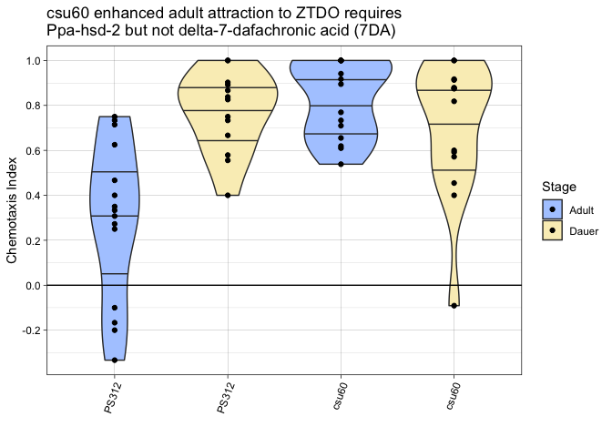

```r
color_palette2 <- c("#AFCBFF", "#FAEEC0")  #Making a custom color palette

#### Plot data

chemotaxis_data %>%   #Start with chemotaxis data frame
  filter(treatment == "none") %>%
  ggplot(aes(x = condition,  #Start ggplot with x mapped to condition
             y = CI,  #Map y to chemotaxis index
             fill = lifestage)) +  #Map fill to life stage
  geom_violin(draw_quantiles = c(0.25, 0.5, 0.75)) +  #Start violin geometry, and draw lines for quantiles
  geom_point() +  #Overlay point geometry for each replicate
  theme_linedraw() +  #Use ggtheme linedraw
  theme(axis.text.x = element_text(angle = 70, hjust = 1)) +  #Angle the text for the x-axis labels
  scale_fill_manual(values = color_palette2, #Use custom color palette
                    name = "Stage", #Change the legend title
                    labels = c("Adult", "Dauer")) +  #Change the legend labels
  scale_x_discrete(name = " ",  #Remove x-axis title
                   labels = c("PS312", "PS312", "csu60", "csu60")) + #Change all the labels under the x-axis
  scale_y_continuous(name = "Chemotaxis Index",  #Change y-axis title
                     n.breaks = 10) +  #Change number of y-axis major breaks to 10
  geom_hline(yintercept = 0) +  #Add a horizontal, y-intercept line at y = 0
  labs(title = "csu60 enhanced adult attraction to ZTDO requires \nPpa-hsd-2 but not delta-7-dafachronic acid (7DA)") #Add a plot title
```

The wild-type strain PS312 responses to ZTDO look as expected - mild attraction to ZTDO in the adult stage, and higher attraction in the dauer stage. Interestingly, the *csu60* mutant adults show elevated attraction to ZTDO that resembles dauer-like attraction.

## Does the *Ppa-hsd-2* mutation change *Ppa-odr-3p::rfp* neuronal expression?

Interestingly, we found that the *Ppa-hsd-2* mutant ectopically expresses a transgenic fluorescent reporter for the gene *Ppa-odr-3* in an extra pair of neurons, compared to just two pairs of neurons in wild type (PS312).

Click [here](https://h-carstensen.shinyapps.io/odr3_slider/) for shiny image slider showing *Ppa-odr-3* expression patterns.

Click [here](https://github.com/Biol551-CSUN/Carstensen_final_project/blob/main/Script/odr3_slider_app/odr3_slider/app.R) to view the code used to make this shiny app.

In *C. elegans*, the *odr-3* gene is involved in response to volatile odors, so this extra expression in *csu60* may be related to the ZTDO chemotaxis phenotype.

## Is *Ppa-odr-3* related to the elevated adult chemotaxis to ZTDO in the *Ppa-hsd-2* mutant?

To determine whether the *csu60* ectopic *Ppa-odr-3* expression is related to the elevated adult attraction to ZTDO observed in *csu60*, I generated *Ppa-odr-3* mutants using the CRISPR-Cas9 mutagenesis. This involves injecting adult worms with Cas9, the necessary RNA molecules, and a co-injection marker that will express RFP in successfully injected worms. I will make a Sankey diagram illustrating the efficiency of my mutagenesis screen.

```r
odr3_data <- read_csv(here("data", "odr3_data.csv"))  #Read in data

head(odr3_data)
```

```
## # A tibble: 6 × 3
##   source           target           value
##   <chr>            <chr>            <dbl>
## 1 Worms injected   Successful          52
## 2 Successful       RFP+ F1s            11
## 3 RFP+ F1s         Heterozygous F1s    28
## 4 RFP+ F1s         Wild-type F1s       17
## 5 Heterozygous F1s Homozygous F2s      10
## 6 Homozygous F2s   Early stop           6
```

```r
#Need to create a data frame with all the nodes that will be used in the Sankey plot.
nodes <- data.frame(  #Start data frame called nodes
  name=c(as.character(odr3_data$source),  #take source node names from odr3_data
         as.character(odr3_data$target)) %>% unique()  #take target node names from odr3_data
)

# To make a Sankey plot with networkD3, connections between the nodes must be provided using ID rather than the real name, so they need to be reformatted.
odr3_data$IDsource <- match(odr3_data$source, nodes$name)-1  #Reformat source nodes
odr3_data$IDtarget <- match(odr3_data$target, nodes$name)-1  #Reformat target nodes

# Make the Network
plot <- sankeyNetwork(Links = odr3_data, #Making a Sankey plot
                      Nodes = nodes,  #setting node values
                   Source = "IDsource",  #Setting source values
                   Target = "IDtarget",  #Setting target values
                   Value = "value",  #Setting flow width values
                   NodeID = "name",  #Setting node names
                   sinksRight=FALSE,  #Making it so that nodes are not on the right border of the plot
                   fontSize = 12)  #Increasing the font size

plot
```

[interactive chart not shown]

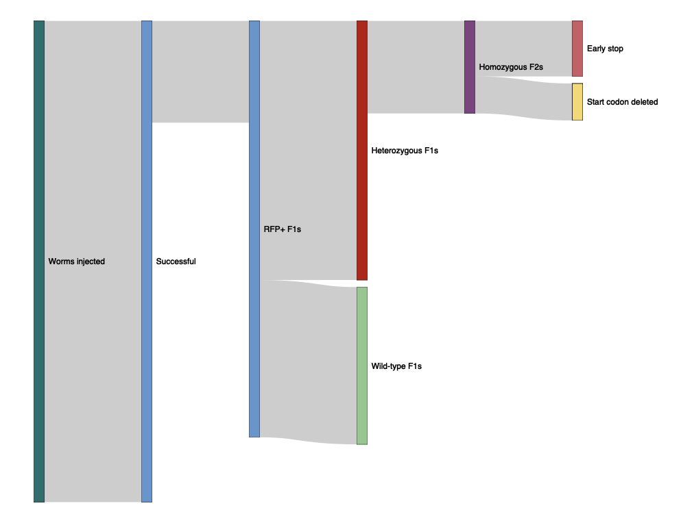

```r
saveWidget(plot, file=paste0( getwd(), "/HtmlWidget/sankey.html"))  #Saving the html widget

webshot(here("HtmlWidget", "sankey.html"), "sankey.png")  #Taking a screenshot of the html widget and saving as a .png
```

Several mutant alleles were generated using CRISPR-Cas9 mutagenesis. The next steps would be to generate a double mutant of *Ppa-hsd-2* and *Ppa-odr-3*, and then test *Ppa-odr-3* mutants and *Ppa-odr-3*;*Ppa-hsd-2* double mutants for ZTDO chemotaxis, to examine whether *Ppa-odr-3* changes the enhanced adult attraction to ZTDO.

Reference: Carstensen HR, Villalon RM, Banerjee N, Hallem EA, Hong RL. 2021. Steroid hormone pathways coordinate developmental diapause and olfactory remodeling in *Pristionchus pacificus*. Genetics. 218:iyab071.